### AdaptWest Climate Metrics Tour

### Climatic connectivity - protecting areas needed for movement in response to climate change

The persistence of many species under climate change will depend areas that facilitate dispersal to newly climatically suitable habitat. Climate connectivity areas or “climate corridors” are areas that form the best route between current climate types and where those climates will occur in the future under climate change. Climate connectivity areas are distinct from refugia and thus poorly captured by many existing conservation strategies. Because dispersing organisms may need to avoid hostile climates, these routes are often circuitous rather than the straight-line paths, as is assumed when measuring standard climatic velocity. [Dobrowski and Parks 2016](https://www.nature.com/articles/ncomms12349) developed a more realistic measure of climatic velocity that is based on this circuitous route rather than a straight-line path. Results from this study can help land managers create more effective responses to climate change by identifying landscape features which promote connectivity among refugia.

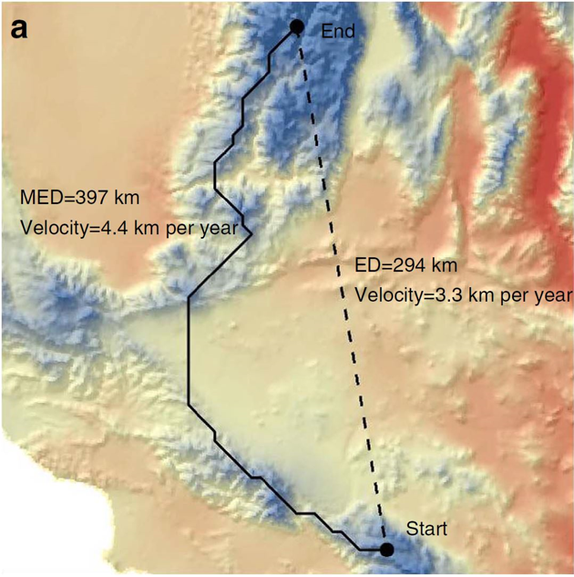

*Figure from [Dobrowski & Parks (2016)](https://www.nature.com/articles/ncomms12349)*

Several methods exist for identifying climate corridors. [Carroll et al. 2018](https://onlinelibrary.wiley.com/doi/full/10.1111/gcb.14373) used centrality metrics to identify areas where many potential dispersal paths overlap. Broad-scale topography and climate influence connectivity paths. Routes were found to be funneled along north-south trending passes and valley systems and along the leeward or drier slopes of north-south trending mountain ranges. Climate connectivity paths also tend to avoid areas of novel and disappearing climates. Human landuses may further constrain the ability of species to disperse through these areas.

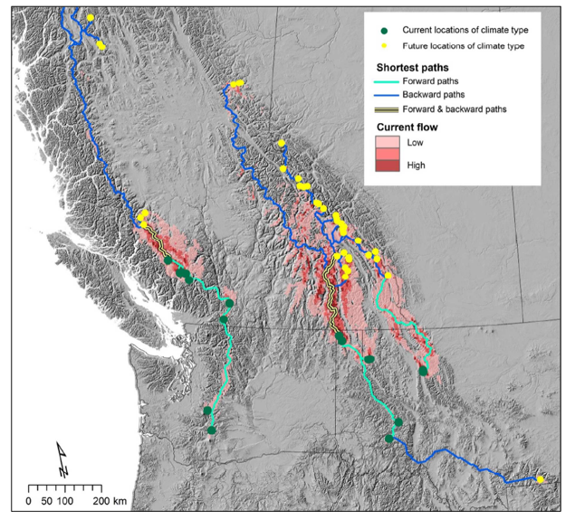

*Figure from [Carroll et al. (2018)](https://onlinelibrary.wiley.com/doi/full/10.1111/gcb.14373)*

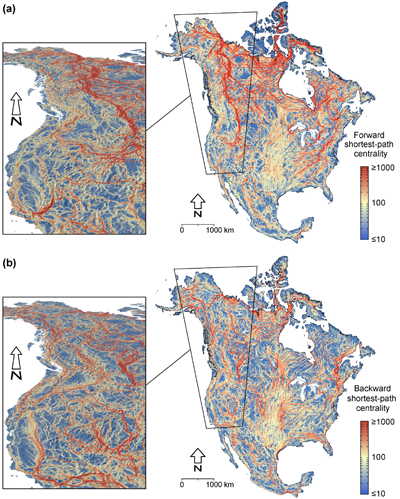

Existing parks and protected areas with high importance for climate connectivity were found in western and arctic Canada and Alaska. Areas within the high Arctic and the western Canadian Cordillera were also found to hold important climate connectivity areas which merit increased conservation focus due to pressures from human land use or due to current low levels of protection.

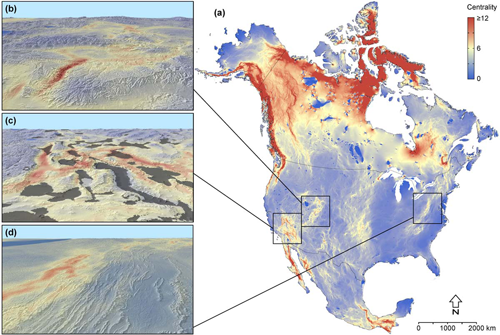